```python
import sys, os, warnings
import plotly
import plotly.graph_objs as go
from IPython.display import display, HTML
from plotly.offline import iplot, plot, init_notebook_mode
from plotly.tools import FigureFactory as FF

plotly.offline.init_notebook_mode()
warnings.filterwarnings('ignore')

def show_plotly_html(filename):
    fp = "htmls_from_plotly/"+filename
    return display(HTML("<iframe src="+fp+" frameborder=0 width=100% height=600></iframe>"))

def save_py_widget(widget, filename, image_width=600):
    fp = "htmls_from_plotly/"+filename
    p = plot(widget, filename=fp, auto_open=False, show_link=False, image_width=image_width)

%load_ext rpy2.ipython

#note: in order to convert notebook into presentation, run following command in terminal:
#jupyter nbconvert prese_meetup_plotly.ipynb --to slides --post serve
```

```
The rpy2.ipython extension is already loaded. To reload it, use:
  %reload_ext rpy2.ipython
```

```python
%%R
library(plotly)
library(ggplot2)
library(htmlwidgets)

save_my_widget <- function(widget, filename){
    d <- file.path(getwd(), "htmls_from_plotly/")
    fp <- file.path(d, filename)
    saveWidget(widget, fp, libdir=paste0(d, 'lib/'), selfcontained=F)
}
#save_my_widget(ply, "py01_diamonds.html")
```

# Interactive Visualization across boundaries: Plotly in R and Python

### Susann Vorberg

PhD student bioinformatics, [Soeding lab](http://www.mpibpc.mpg.de/de/soeding), LMU

### Daniel Bader

PhD student computational biology, [Gagneur lab](https://www.gagneurlab.in.tum.de), TUM

## What is Plotly?

- JavaScript graphing library **plotly.js**
- build on top of D3 --> interactivity!
- **plotly.js** went open-source in Nov 2015
- graphs are specified declaratively in JSON format

```python
{
    "data": [
        {
            "x":[1,2,3],
            "y":[2,3,4]
        }
    ],
    "layout" : {
        "title":"Plotly Plot"
    }
}
```

```
{'data': [{'x': [1, 2, 3], 'y': [2, 3, 4]}],
 'layout': {'title': 'Plotly Plot'}}
```

http://www.plot.ly

## What else is Plotly?

- API libraries for Python, R, Julia, Scala, ...
- directly convert ggplot, pandas or matplotlib plots into interactive D3 plots
- embed interactive Plotly plots into
  - jupyter/ipython notebooks
  - knitr reports
  - Shiny Apps

https://plot.ly/api/

## Remember ggplot from last meetup? Now comes: ggplotly

**ggplotly** works by serializing ggplot2 figures into plotly's universal graph JSON.

Create a sophisticated plot in R with ggplot...

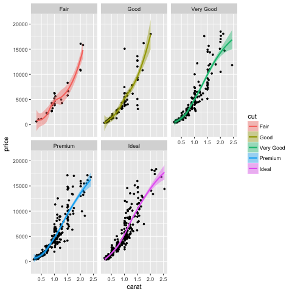

```python
%%R
library(ggplot2)

d <- diamonds[sample(nrow(diamonds), 1000), ]
p <- ggplot(data = d, aes(x = carat, y = price)) +
        geom_point(size = 1) +
        geom_smooth(aes(colour = cut, fill = cut)) +
        facet_wrap(~ cut)
print(p)
```

And convert this plot into a fancy interactive plot with **just one command**...

```python
%%R
library(plotly)
ply <- ggplotly(p)
save_my_widget(ply, "py01_diamonds.html")
```

```python
show_plotly_html("py01_diamonds.html")
```

[interactive chart not shown]

## Building blocks of visualizations

- visual objects used to encode quantitative values
  - dots
  - lines
  - shapes
- data types
  - quantitative
  - categorical

The Grammar of Graphics is a visualization theory developed by Leland Wilkinson in 1999.

- influenced the development of graphics and visualization libraries alike
- focus on 3 of its key principles
  - Separation of data from aesthetics (e.g. in ggplot)
  - Definition of common plot/chart elements
  - Composition of these common elements

## "Hello meetup" example in R

```python
%%R -o df
df <- data.frame(
  categorical = c("A", "B", "C"), quantitative = c(1,2,3)
)
p <-  plot_ly(
        df, x=~categorical, y=~quantitative, type='scatter', mode='markers'
    ) %>%
    add_trace( x=~categorical, y=~quantitative, mode='markers+lines') %>%
    add_trace( x=~categorical, y=~quantitative, type='bar') %>%
    layout(title='Hello meetup')
save_my_widget(p, "pr01_triple_basics.html")
```

```python
show_plotly_html("pr01_triple_basics.html")
```

[interactive chart not shown]

## Hello world example in Python

```python
import plotly.graph_objs as go

trace1 = go.Scatter(
    x = df.categorical.tolist(),
    y = df.quantitative.values,
    mode ='markers')

trace2 = go.Scatter(
    x = df.categorical.tolist(),
    y = df.quantitative.values,
    mode ='lines')

trace3 = go.Bar(
    x = df.categorical.tolist(),
    y = df.quantitative.values)

#define data and layout
data   = [trace1, trace2, trace3]
layout = go.Layout(
    title = "Hello meetup",
    xaxis = dict(title = "categorical"),
    yaxis = dict(title = "quantitative")
)

#define plot
fig = go.Figure(data=data, layout=layout)
#p = plot(fig, filename="pp_triple_basics.html", auto_open=False, show_link=False)
save_py_widget(fig, "pp_triple_basics.html")
```

```python
show_plotly_html("pp_triple_basics.html")
```

[interactive chart not shown]

## Careful with datasets

Pokemon Index data from Tableau website: https://public.tableau.com/s/resources

[figure not shown]

```python
%%R -o poke_stats
poke_stats <- read.delim('data_pokemon_stats.tsv', stringsAsFactor=F)
```

```python
poke_stats.head()
```

|  | Name | Type | Total | HP | Attack | Defense | Special_Attack | Special_Defense | Speed |
| --- | --- | --- | --- | --- | --- | --- | --- | --- | --- |
| 1 | Bulbasaur | GRASS | 318 | 45 | 49 | 49 | 65 | 65 | 45 |
| 2 | Bulbasaur | POISON | 318 | 45 | 49 | 49 | 65 | 65 | 45 |
| 3 | Ivysaur | GRASS | 405 | 60 | 62 | 63 | 80 | 80 | 60 |
| 4 | Ivysaur | POISON | 405 | 60 | 62 | 63 | 80 | 80 | 60 |
| 5 | Venusaur | GRASS | 525 | 80 | 82 | 83 | 100 | 100 | 80 |

## Bubble Chart in R

```python
%%R
# type = [bar|scatter]
# mode = [markers|lines], if type=="scatter"

p <- plot_ly(
    data=subset(poke_stats, Type %in% c('GRASS', 'FIRE', 'WATER')),
    x=~Total, y=~Attack,
    type='scatter',
    size=~Defense,
    color=~Type,
    text=~paste("Name:", Name,"<br>Defense:",Defense)
)
save_my_widget(p, "pr_poke_bubble.html")
```

```python
show_plotly_html("pr_poke_bubble.html")
```

[interactive chart not shown]

## Bubble Chart in Python

```python
data = [
    go.Scatter(
        x=poke_stats[poke_stats.Type == type]['Total'].values,
        y=poke_stats[poke_stats.Type == type]['Attack'].values,
        name = type,
        mode='markers',
        marker = dict(
            size=poke_stats[poke_stats.Type == type]['Defense'].values /2
        )
    ) for type in ["GRASS","WATER", "FIRE"]
]

layout=go.Layout(
    xaxis=dict(title='Total'),
    yaxis=dict(title='Attack')
)

fig = go.Figure(data=data, layout=layout)
save_py_widget(fig, "pp_bubblechart.html")
```

```python
show_plotly_html("pp_bubblechart.html")
```

[interactive chart not shown]

## Stacked bar chart in R

```python
%%R
p <- plot_ly(
    subset(poke_stats, Name %in% c('Squirtle','Bulbasaur','Charmander')),
     x = ~Name,
     y = ~Attack, type = 'bar', name="Attack"
) %>% add_trace(
    y=~Defense, name='Defense'
) %>% layout(
    barmode = 'stack'
)
save_my_widget(p, "pr_poke_stackedbar.html")
```

```python
show_plotly_html("pr_poke_stackedbar.html")
```

[interactive chart not shown]

## Boxplot in R

```python
%%R
p <- plot_ly(
    data=subset(poke_stats, Type %in% c('GRASS', 'FIRE', 'WATER')),
    x=~Type, y=~Attack,
    type='box'
    ,boxpoints='all', jitter = 0.0, pointpos = -2

)
save_my_widget(p, "pr_poke_box.html")
```

```python
show_plotly_html("pr_poke_box.html")
```

[interactive chart not shown]

## Boxplot in Python

```python
pybox = [ go.Box(
    y=poke_stats[poke_stats.Type == type]["Attack"].tolist(),
    name=type,
    boxpoints='all',
    jitter=0.0,
    pointpos = -2
    ) for type in ["GRASS","WATER", "FIRE"]]


save_py_widget(pybox, "pp_boxplot.html")
```

```python
show_plotly_html("pp_boxplot.html")
```

[interactive chart not shown]

## Distribution Plots in Python

```python
hist_data = [poke_stats.Attack, poke_stats.Defense]
group_labels = ['Attack', 'Defense']
rug_text = [poke_stats.Name, poke_stats.Name]

fig = FF.create_distplot(
    hist_data,
    group_labels,
    bin_size=10,
    rug_text=rug_text,
    show_hist=True, show_curve=True, show_rug=True)

save_py_widget(fig, "pp_density.html", image_width=800)
```

```python
show_plotly_html("pp_density.html")
```

[interactive chart not shown]

## 2D Distribution Plots in Python

```python
x = poke_stats.Attack.values
y = poke_stats.Defense.values

fig = FF.create_2D_density(
    x,
    y,
    point_size=5,
    title="Distribution of Attack Points vs Defense Points"
)

save_py_widget(fig, "pp_density2d.html", image_width=800)
```

```python
show_plotly_html("pp_density2d.html")
```

[interactive chart not shown]

## Heatmap

```python
%%R
# pokemon picture: https://img.pokemondb.net/artwork/bulbasaur.jpg
get_poke_link <- function(name){
    paste0("https://img.pokemondb.net/artwork/",tolower(name),".jpg")
}
show_linked_name <- function(name){
    link = get_poke_link(name)
    paste0('<a href="',link,'">',name,'</a>')
}
```

```python
%%R
df <- subset(poke_stats, Type %in% c('BUG', 'DRAGON'))
cn_stats = c('HP', 'Attack', 'Defense', 'Speed')
# hierarchical clustering
df <- df[hclust(dist(df[,cn_stats]))$order,]

p <- plot_ly(
    df, y=sapply(df$Name, show_linked_name), x=cn_stats,
    # give matrix for heatmap
    z=as.matrix(df[,cn_stats]), type='heatmap', colors = colorRamp(c("gray", "blue"))
    ) %>% layout(
        # default: sort names alphabetically :-(
        margin=list(l=70), xaxis=list(categoryorder ='trace'), yaxis=list(categoryorder ='trace')
    )
save_my_widget(p, "pr_poke_heatmap.html")
```

```python
show_plotly_html("pr_poke_heatmap.html")
```

[interactive chart not shown]

## We are hiring people from everywhere

```python
%%R
people <- data.frame(
    loc=c('France', 'Germany', 'Slovenia', 'Russia', 'Turkey', 'Ecuador', 'Colombia', 'Bangladesh', 'China'),
    num=c(1, 3, 1, 1, 1, 1, 1, 1, 1)
)
p <- plot_ly(people, type='choropleth', locationmode='country names',
     locations=~loc, z=~num, colors=colorRamp(c("gray", "red"))
    ) %>% layout(
    title='The world-wide gagneur lab',
    geo=list(scope='world', projection=list(type='natural earth'))
)
save_my_widget(p, "pr_gagneur_map.html")
```

```python
show_plotly_html("pr_gagneur_map.html")
```

[interactive chart not shown]